# STATS 205: Homework Assignment 3

Brian Liu

4/26/2019

## Solution to Problem 1

### (i)

```r
library(bootstrap); data(law)
t(law)
```

```
##           1     2      3      4      5      6   7      8      9     10
## LSAT 576.00 635.0 558.00 578.00 666.00 580.00 555 661.00 651.00 605.00
## GPA    3.39   3.3   2.81   3.03   3.44   3.07   3   3.43   3.36   3.13
##          11     12     13     14     15
## LSAT 653.00 575.00 545.00 572.00 594.00
## GPA    3.12   2.74   2.76   2.88   2.96
```

```r
theta.hat = cor(law$LSAT, law$GPA); theta.hat
```

```
## [1] 0.7763745
```

```r
library(partitions)
n = 15
allCompositions = compositions(n, n);allCompositions[,1:5]
```

```
##       [,1] [,2] [,3] [,4] [,5]
##  [1,]   15   14   13   12   11
##  [2,]    0    1    2    3    4
##  [3,]    0    0    0    0    0
##  [4,]    0    0    0    0    0
##  [5,]    0    0    0    0    0
##  [6,]    0    0    0    0    0
##  [7,]    0    0    0    0    0
##  [8,]    0    0    0    0    0
##  [9,]    0    0    0    0    0
## [10,]    0    0    0    0    0
## [11,]    0    0    0    0    0
## [12,]    0    0    0    0    0
## [13,]    0    0    0    0    0
## [14,]    0    0    0    0    0
## [15,]    0    0    0    0    0
```

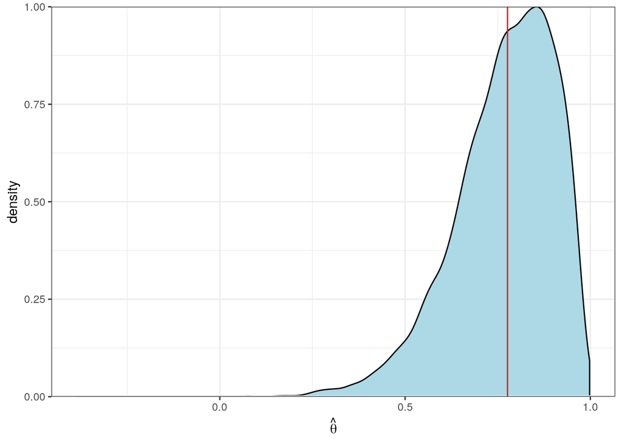

```r
allCompositions.sub = allCompositions[, sample(1:dim(allCompositions)[2], size=10000, replace=FALSE)]

draw.bootstrap.samples = function(df){
  n = dim(df)[1]
  ind = sample(n, replace = TRUE)
  cor.bootstrap.replicate = cor(df[ind, "LSAT"], df[ind, "GPA"])
  return(cor.bootstrap.replicate)
}
R = 10000
theta.hat.star = replicate(R, draw.bootstrap.samples(law))
# make a ggplot
library(ggplot2)
theta.hat.star.df = data.frame(theta.hat.star = theta.hat.star)
ggplot(theta.hat.star.df) +
  geom_density(aes(x = theta.hat.star, y = ..scaled..),
    fill = "lightblue") +
  geom_hline(yintercept=0, colour="white", size=1) +
  theme_bw() +
  ylab("density") +
  xlab(bquote(hat(theta))) +
  geom_vline(xintercept = theta.hat, col = "red")+
  scale_y_continuous(expand = c(0,0))
```

### (ii)

```r
sd(theta.hat.star)
```

```
## [1] 0.1348461
```

## Solution to Problem 2

### (i)

```
67 runs resulting in swallowing attempts
58 successful
9 failed

H_0 : p = 0.6
H_A : p > 0.6
```

```r
n = 67
successes = 58
pbar = successes / n; pbar
```

```
## [1] 0.8656716
```

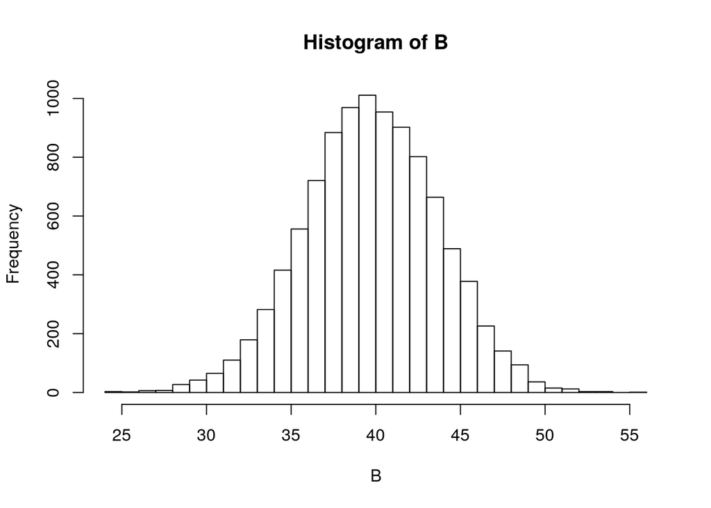

```r
p0 = 0.6; nsim = 10000
B = rbinom(nsim, size = n, prob = p0)
hist(B, breaks = 30)
```

Test statistic $Z$:

$$Z_0 = \frac{B - 67(0.6)}{(67(0.6)(0.4))^{\frac{1}{2}}}$$

```r
qnorm((1-0.05), mean = 0, sd = 1)
```

```
## [1] 1.644854
```

Rejection region: $Z \geq z_{0.05} = 1.645$

Observed test statistic $Z_o$:

$$Z_o = \frac{58 - 67(0.6)}{(67(0.6)(0.4))^{\frac{1}{2}}} = 4.44$$

```r
numerator = successes - (n * p0)
denominator = sqrt(n * p0 * (1.0 - p0))
Z.obs = numerator / denominator; Z.obs
```

```
## [1] 4.438917
```

### (ii)

Power is the probability of rejecting $H_0$ when $H_A$ is true. We found that test reject $H_0$ is $Z \geq z_{0.05} = 1.645$. Therefore, if $p = 0.7$,

$$Z_o = \frac{58 - 67(0.6)}{(67(0.6)(0.4))^{\frac{1}{2}}} = 4.44$$

is no longer standard normal.

We have

$$Z_{o7} = \frac{58 - 67(0.7)}{(67(0.7)(0.3))^{\frac{1}{2}}} = 2.96$$

```r
p1 = 0.7
numerator = successes - (n * p1)
denominator = sqrt(n * p1 * (1.0 - p1))
Z.obs.seven = numerator / denominator; Z.obs.seven
```

```
## [1] 2.959211
```

$$Power = P(Z \geq 1.645 | p = 0.7)$$

$$= P_{p = 0.7}\bigg(\frac{B - 67(0.6)}{(67(0.6)(0.4))^{\frac{1}{2}}} \geq 1.645\bigg)$$

$$= P_{p = 0.7}(B \geq 1.645(67(0.6)(0.4))^{\frac{1}{2}} + 67(0.6))$$

$$= P_{p=0.7}\bigg(\frac{B - 67(0.7)}{(67(0.7)(0.3))^{\frac{1}{2}}} \geq \frac{1.645(67(0.6)(0.4))^{\frac{1}{2}} + 67(0.6) - 67(0.7)}{(67(0.7)(0.3))^{\frac{1}{2}}}\bigg)$$

```r
triple_product = n * p0 * (1.0 - p0)
first_term = 1.645 * sqrt(triple_product)
second_term = n * p0
third_term = n * p1
bottom_term = n * p1 * (1.0 - p1)
p7_numerator = first_term + second_term - third_term
p7_denominator = sqrt(bottom_term)
Pp_7_zvalue = p7_numerator / p7_denominator; Pp_7_zvalue
```

```
## [1] -0.02761144
```

```r
power7 = pnorm(Pp_7_zvalue); power7
```

```
## [1] 0.488986
```

If $p = 0.8$,

$$Power = P(Z \geq 1.645 | p = 0.8)$$

$$= P_{p=0.8}\bigg(\frac{B - 67(0.8)}{(67(0.8)(0.2))^{\frac{1}{2}}} \geq \frac{1.645(67(0.6)(0.4))^{\frac{1}{2}} + 67(0.6) - 67(0.8)}{(67(0.8)(0.2))^{\frac{1}{2}}}\bigg)$$

```r
p2 = 0.8
triple_product = n * p0 * (1.0 - p0)
first_term = 1.645 * sqrt(triple_product)
second_term = n * p0
third_term = n * p2
bottom_term = n * p2 * (1.0 - p2)
p8_numerator = first_term + second_term - third_term
p8_denominator = sqrt(bottom_term)
Pp_8_zvalue = p8_numerator / p8_denominator; Pp_8_zvalue
```

```
## [1] -2.077971
```

```r
power8 = pnorm(Pp_8_zvalue); power8
```

```
## [1] 0.01885601
```

## Solution to Problem 3

**Summary**: **Estimate** for $\hat{p} = 0.8615$ and **estimate for standard deviation** of $\hat{p} = 0.04284$.

Estimate for $p$ using binomial confidence interval, `binom.confint()`:

```r
library(binom)
binom.confint(x=56, n=65, conf.level=.95, methods = "asymptotic")
```

```
##       method  x  n      mean     lower     upper
## 1 asymptotic 56 65 0.8615385 0.7775744 0.9455025
```

$$\hat{p} = (0.7776, 0.9455)$$

```r
prop.test(x=56, n=65, p = 0.6, conf.level=0.95, alternative = c("greater"))
```

```
##
##  1-sample proportions test with continuity correction
##
## data:  56 out of 65, null probability 0.6
## X-squared = 17.452, df = 1, p-value = 1.473e-05
## alternative hypothesis: true p is greater than 0.6
## 95 percent confidence interval:
##  0.7676875 1.0000000
## sample estimates:
##         p
## 0.8615385
```

$$p = 0.8615$$

Estimate for $p$ using `Exact binomial test`:

```r
binom.test(x=56, n=65, p = 0.6, alternative = c("greater"), conf.level = 0.95)
```

```
##
##  Exact binomial test
##
## data:  56 and 65
## number of successes = 56, number of trials = 65, p-value =
## 4.096e-06
## alternative hypothesis: true probability of success is greater than 0.6
## 95 percent confidence interval:
##  0.7708174 1.0000000
## sample estimates:
## probability of success
##              0.8615385
```

Standard error of $\hat{p}$ is:

$$\sqrt{\frac{p(1 - p)}{n}}$$
$$= \sqrt{\frac{(0.6)(0.4)}{65}}$$
$$= 0.06076$$

```r
p = 0.6
n = 65
numerator = p * (1 - p)
denominator = n
answer = sqrt(numerator/denominator); answer
```

```
## [1] 0.06076436
```

and estimate is:

$$\sqrt{\frac{\hat{p}(1 - \hat{p})}{n}}$$
$$= \sqrt{\frac{(0.8615)(1 - 0.8615)}{65}}$$
$$= 0.04284$$

```r
p.hat = 0.8615
n = 65
numerator = p.hat * (1 - p.hat)
denominator = n
answer = sqrt(numerator/denominator); answer
```

```
## [1] 0.04284458
```

## Solution to Problem 4

```r
binom.confint(x = 56, n = 65, conf.level = 0.96, methods = "all")
```

```
##           method  x  n      mean     lower     upper
## 1  agresti-coull 56 65 0.8615385 0.7488973 0.9301180
## 2     asymptotic 56 65 0.8615385 0.7735567 0.9495202
## 3          bayes 56 65 0.8560606 0.7655984 0.9375798
## 4        cloglog 56 65 0.8615385 0.7439982 0.9276404
## 5          exact 56 65 0.8615385 0.7480632 0.9371740
## 6          logit 56 65 0.8615385 0.7484912 0.9286194
## 7         probit 56 65 0.8615385 0.7545841 0.9312980
## 8        profile 56 65 0.8615385 0.7589798 0.9334925
## 9            lrt 56 65 0.8615385 0.7589836 0.9335307
## 10     prop.test 56 65 0.8615385 0.7483484 0.9308913
## 11        wilson 56 65 0.8615385 0.7514483 0.9275670
```

Here are the rows relevant to our problem:

```
##           method  x  n      mean     lower     upper
## 1  agresti-coull 56 65 0.8615385 0.7488973 0.9301180
## 2     asymptotic 56 65 0.8615385 0.7735567 0.9495202
## 5          exact 56 65 0.8615385 0.7480632 0.9371740
## 11        wilson 56 65 0.8615385 0.7514483 0.9275670
```

where `asymptotic` is Laplace-Wald, `agresti-coull` is Agresti-Coull, `exact` is Clopper-Pearson, and `wilson` is Wilson.

## Solution to Problem 5

```r
plant_vector <- c(926, 288, 293, 104)

expected = c(9/16, 3/16, 3/16, 1/16)

# goodness-of-fit test

res <- chisq.test(x = plant_vector, p = expected); res
```

```
##
##  Chi-squared test for given probabilities
##
## data:  plant_vector
## X-squared = 1.4687, df = 3, p-value = 0.6895
```

```r
res$expected
```

```
## [1] 906.1875 302.0625 302.0625 100.6875
```

```r
res$observed
```

```
## [1] 926 288 293 104
```

The **p-value** of the test is $p = 0.6895$, which is more than the significance level $\alpha = 0.05$. We cannot conclude that the data does *not* support Mendelian theory at the $\alpha = 0.05$ level.

## Solution to Problem 6

```r
df = data.frame(Low = c(0, 2), High = c(5, 1))
rownames(df) = c("Multiple attack", "Primary attack"); df
```

```
##                 Low High
## Multiple attack   0    5
## Primary attack    2    1
```

```r
fisher.test(df, alternative = "less")
```

```
##
##  Fisher's Exact Test for Count Data
##
## data:  df
## p-value = 0.1071
## alternative hypothesis: true odds ratio is less than 1
## 95 percent confidence interval:
##  0.00000 1.75251
## sample estimates:
## odds ratio
##          0
```

There is *not enough evidence* that the unknown probability that a multiple-attack patient will have low reactivity is *less than* the unknown probability that a primary-attack patient will have low reactivity at the $\alpha = 0.05$ level. The $P$-value achieved by these data if we use Fisher’s exact test of $H_0$ against the alternative $p_1 < p_2$ is $0.1071$.

```r
df = data.frame(Low = c(0, 2), High = c(5, 1))
rownames(df) = c("Multiple attack", "Primary attack"); df
```

```
##                 Low High
## Multiple attack   0    5
## Primary attack    2    1
```

```r
fisher.test(df, alternative = "two.sided")
```

```
##
##  Fisher's Exact Test for Count Data
##
## data:  df
## p-value = 0.1071
## alternative hypothesis: true odds ratio is not equal to 1
## 95 percent confidence interval:
##  0.00000 2.75184
## sample estimates:
## odds ratio
##          0
```

The $P$-value achieved when testing the null against a two-sided hypothesis is the same, $0.1071$, and therefore, there is still *not enough evidence* that the unknown probability that a multiple-attack patient will have low reactivity is *not equal* to the unknown probability that a primary-attack patient will have low reactivity.

## Solution to Problem 7

Since we want to find out if having tonsils reduces the rate of Hodgkin’s, we want to see if there is a higher rate of tonsillectomy among Hodgkin’s cases than among non-Hodgkin’s cases. Therefore, we will test the null hypothesis that there is no difference in the rate of tonsillectomy between the two populations of Hodgkin’s and non-Hodgkin’s cases against the alternative hypothesis that there is higher rate of tonsillectomy among Hodgkin’s cases.

$$H_0 : p_1 = p_2$$

$$H_A : p_1 > p_2$$

```r
x = c(67, 43)
n = c(101, 107)
prop.test(x, n, alternative = c("greater"), conf.level = 0.99)
```

```
##
##  2-sample test for equality of proportions with continuity
##  correction
##
## data:  x out of n
## X-squared = 13.229, df = 1, p-value = 0.0001379
## alternative hypothesis: greater
## 99 percent confidence interval:
##  0.09655707 1.00000000
## sample estimates:
##    prop 1    prop 2
## 0.6633663 0.4018692
```

The 99% confidence interval for difference between rate of tonsillectomy in Hodgkin’s cases and rate of tonsillectomy in non-Hodgkin’s cases is between 9.66% and 100%.

The $P$-value achieved by these data if we use a `2-sample test for equality of proportions with continuity correction` is $0.0001379$. There is *strong evidence* at the $\alpha = 0.05$ level that there is higher rate of tonsillectomy among Hodgkin’s cases.

## Solution to Problem 8

```r
elisa_matrix <- matrix(c(82, 13, 6, 0), nrow=2, ncol=2, byrow=TRUE, dimnames = list("ABC-ELISA" = c("+", "-"), "Standard ELISA" = c("+", "-"))); elisa_matrix
```

```
##          Standard ELISA
## ABC-ELISA  +  -
##         + 82 13
##         -  6  0
```

```r
# prop.test(x = elisa_matrix) <-- this produced a p value not less than 0.005, so I may be using it wrong

mcnemar.test(x = elisa_matrix)
```

```
##
##  McNemar's Chi-squared test with continuity correction
##
## data:  elisa_matrix
## McNemar's chi-squared = 1.8947, df = 1, p-value = 0.1687
```

## Solution to Problem 9

```r
ptsd_matrix <- matrix(c(29, 7, 21, 30), nrow = 2, ncol = 2, byrow = TRUE, dimnames = list(c("Yes", "No"), c("Battered women", "Maritally distressed women who had not experienced battering"))); ptsd_matrix
```

```
##     Battered women
## Yes             29
## No              21
##     Maritally distressed women who had not experienced battering
## Yes                                                            7
## No                                                            30
```

```r
prop.test(ptsd_matrix, correct = F, alternative = "two.sided")
```

```
##
##  2-sample test for equality of proportions without continuity
##  correction
##
## data:  ptsd_matrix
## X-squared = 13.389, df = 1, p-value = 0.0002531
## alternative hypothesis: two.sided
## 95 percent confidence interval:
##  0.2068191 0.5807626
## sample estimates:
##    prop 1    prop 2
## 0.8055556 0.4117647
```

The $P$-value for `2-sample test for equality of proportions without continuity correction` is $0.0002531$, which is significant at the $\alpha = 0.05$ level. There is strong evidence that there is a significant difference in the PTSD rates for battered women versus maritally distressed women (who had not experienced battering).